# Modern Data Mining, HW 1

Yuzhou Lin

Lingqi Zhang

Shaolong Wu

Due: 11:59PM, February 7, 2021

# 1 Overview

This is a fast-paced course that covers a lot of material. There will be a large amount of references. You may need to do your own research to fill in the gaps in between lectures and homework/projects. It is impossible to learn data science without getting your hands dirty. Please budget your time evenly. Last-minute work ethic will not work for this course.

Homework in this course is different from your usual homework assignment as a typical student. Most of the time, they are built over real case studies. While you will be applying methods covered in lectures, you will also find that extra teaching materials appear here. The focus will be always on the goals of the study, the usefulness of the data gathered, and the limitations in any conclusions you may draw. Always try to challenge your data analysis in a critical way. Frequently, there are no unique solutions.

Case studies in each homework can be listed as your data science projects (e.g. on your CV) where you see fit.

## 1.1 Objectives

- Get familiar with `R-studio` and `RMarkdown`
- Hands-on R
- Learn data science essentials
  - gather data
  - clean data
  - summarize data
  - display data
  - conclusion
- Packages
  - `dplyr`
  - `ggplot`

## 1.2 Instructions

- **Homework assignments can be done in a group consisting of up to three members**. Please find your group members as soon as possible and register your group on our Canvas site.
- **All work submitted should be completed in the R Markdown format.** You can find a cheat sheet for R Markdown [here](https://github.com/rstudio/cheatsheets/raw/master/rmarkdown-2.0.pdf). For those who have never used it before, we urge you to start this homework as soon as possible.
- **Submit the following files, one submission for each group:** (1) Rmd file, (2) a compiled PDF or HTML version, and (3) all necessary data files if different from our source data. You may directly edit this .rmd file to add your answers. If you intend to work on the problems separately within your group, compile your answers into one Rmd file before submitting. We encourage that you at least attempt each problem by yourself before working with your teammates. Additionally, ensure that you can ‘knit’ or compile your Rmd file. It is also likely that you need to configure Rstudio to properly convert files to PDF. [**These instructions**](http://kbroman.org/knitr_knutshell/pages/latex.html#converting-knitrlatex-to-pdf) might be helpful.
- In general, be as concise as possible while giving a fully complete answer to each question. All necessary datasets are available in this homework folder on Canvas. Make sure to document your code with comments (written on separate lines in a code chunk using a hashtag `#` before the comment) so the teaching fellows can follow along. R Markdown is particularly useful because it follows a ‘stream of consciousness’ approach: as you write code in a code chunk, make sure to explain what you are doing outside of the chunk.
- A few good or solicited submissions will be used as sample solutions. When those are released, make sure to compare your answers and understand the solutions.

## 1.3 Review materials

- Study Advanced R Tutorial (to include `dplyr` and `ggplot`)
- Study lecture 1: Data Acquisition and EDA

# 2 Case study 1: Audience Size

How successful is the Wharton Talk Show [Business Radio Powered by the Wharton School](https://businessradio.wharton.upenn.edu/)

**Background:** Have you ever listened to [SiriusXM](https://www.siriusxm.com/)? Do you know there is a **Talk Show** run by Wharton professors in Sirius Radio? Wharton launched a talk show called [Business Radio Powered by the Wharton School](https://businessradio.wharton.upenn.edu/) through the Sirius Radio station in January of 2014. Within a short period of time the general reaction seemed to be overwhelmingly positive. To find out the audience size for the show, we designed a survey and collected a data set via MTURK in May of 2014. Our goal was to **estimate the audience size**. There were 51.6 million Sirius Radio listeners then. One approach is to estimate the proportion of the Wharton listeners to that of the Sirius listeners, $p$, so that we will come up with an audience size estimate of approximately 51.6 million times $p$.

To do so, we launched a survey via Amazon Mechanical Turk ([MTurk](https://www.mturk.com/)) on May 24, 2014 at an offered price of $0.10 for each answered survey. We set it to be run for 6 days with a target maximum sample size of 2000 as our goal. Most of the observations came in within the first two days. The main questions of interest are “Have you ever listened to Sirius Radio” and “Have you ever listened to Sirius Business Radio by Wharton?”. A few demographic features used as control variables were also collected; these include Gender, Age and Household Income.

We requested that only people in United States answer the questions. Each person can only fill in the questionnaire once to avoid duplicates. Aside from these restrictions, we opened the survey to everyone in MTurk with a hope that the sample would be more randomly chosen.

The raw data is stored as `Survey_results_final.csv` on Canvas.

## 2.1 Data preparation

1. We need to clean and select only the variables of interest.

Select only the variables Age, Gender, Education Level, Household Income in 2013, Sirius Listener?, Wharton Listener? and Time used to finish the survey.

Change the variable names to be “age”, “gender”, “education”, “income”, “sirius”, “wharton”, “worktime”.

2. Handle missing/wrongly filled values of the selected variables

As in real world data with user input, the data is incomplete, with missing values, and has incorrect responses. There is no general rule for dealing with these problems beyond “use common sense.” In whatever case, explain what the problems were and how you addressed them. Be sure to explain your rationale for your chosen methods of handling issues with the data. Do not use Excel for this, however tempting it might be.

Tip: Reflect on the reasons for which data could be wrong or missing. How would you address each case? For this homework, if you are trying to predict missing values with regression, you are definitely overthinking. Keep it simple.

3. Brief summary

Write a brief report to summarize all the variables collected. Include both summary statistics (including sample size) and graphical displays such as histograms or bar charts where appropriate. Comment on what you have found from this sample. (For example - it’s very interesting to think about why would one work for a job that pays only 10cents/each survey? Who are those survey workers? The answer may be interesting even if it may not directly relate to our goal.)

## 2.2 Sample properties

The population from which the sample is drawn determines where the results of our analysis can be applied or generalized. We include some basic demographic information for the purpose of identifying sample bias, if any exists. Combine our data and the general population distribution in age, gender and income to try to characterize our sample on hand.

1. Does this sample appear to be a random sample from the general population of the USA?
2. Does this sample appear to be a random sample from the MTURK population?

Note: You can not provide evidence by simply looking at our data here. For example, you need to find distribution of education in our age group in US to see if the two groups match in distribution. You may need to gather some background information about the MTURK population to have a slight sense if this particular sample seem to a random sample from there… Please do not spend too much time gathering evidence.

## 2.3 Final estimate

Give a final estimate of the Wharton audience size in January 2014. Assume that the sample is a random sample of the MTURK population, and that the proportion of Wharton listeners vs. Sirius listeners in the general population is the same as that in the MTURK population. Write a brief executive summary to summarize your findings and how you came to that conclusion.

To be specific, you should include:

1. Goal of the study
2. Method used: data gathering, estimation methods
3. Findings
4. Limitations of the study.

## 2.4 New task

Now suppose you are asked to design a study to estimate the audience size of Wharton Business Radio Show as of today: Jan of 2021. You are given a budget of $1000. You need to present your findings in March 1.

Write a proposal for this study which includes:

1. Method proposed to estimate the audience size.
2. What data should be collected and where it should be sourced from.

A good proposal will give an accurate estimation with the least amount of money used.

# 3 Case study 2: Women in Science

Are women underrepresented in science in general? How does gender relate to the type of educational degree pursued? Does the number of higher degrees increase over the years? In an attempt to answer these questions, we assembled a data set (`WomenData_06_16.xlsx`) from [NSF](https://ncses.nsf.gov/pubs/nsf19304/digest/field-of-degree-women) about various degrees granted in the U.S. from 2006 to 2016. It contains the following variables: Field (Non-science-engineering (`Non-S&E`) and sciences (`Computer sciences`, `Mathematics and statistics`, etc.)), Degree (`BS`, `MS`, `PhD`), Sex (`M`, `F`), Number of degrees granted, and Year.

Our goal is to answer the above questions only through EDA (Exploratory Data Analyses) without formal testing. We have provided sample R-codes in the appendix to help you if needed.

## 3.1 Data preparation

1. Understand and clean the data

Notice the data came in as an Excel file. We need to use the package `readxl` and the function `read_excel()` to read the data `WomenData_06_16.xlsx` into R.

1. Read the data into R.

```r
wsci <- read_excel(file.path(".", "data", "WomenData_06_16.xlsx"))
names(wsci)
```

2. Clean the names of each variables. (Change variable names to `Field`,`Degree`, `Sex` and `Number` )
3. Set the variable natures properly.

```r
wsci %<>%
  rename(Field = "Field and sex",
         Number = "Degrees Awarded") %>%
  mutate(Field = as.factor(Field),
         Degree = as.factor(Degree),
         Sex = as.factor(Sex))
```

4. Any missing values?

**Student Answer:** There are no missing values in this dataset.

```r
summary(wsci)
```

```
##                                     Field     Degree        Sex
##  Agricultural sciences                 : 66   BS :220   Female:330
##  Biological sciences                   : 66   MS :220   Male  :330
##  Computer sciences                     : 66   PhD:220
##  Earth, atmospheric, and ocean sciences: 66
##  Engineering                           : 66
##  Mathematics and statistics            : 66
##  (Other)                               :264
##       Year          Number
##  Min.   :2006   Min.   :   218
##  1st Qu.:2008   1st Qu.:  2118
##  Median :2011   Median :  6020
##  Mean   :2011   Mean   : 41717
##  3rd Qu.:2014   3rd Qu.: 18127
##  Max.   :2016   Max.   :781474
##
```

2. Write a summary describing the data set provided here.
1. How many fields are there in this data?

**Student Answer:** There are 10 fields in this dataset.

```r
group_by(wsci, Field) %>%
  summarise(Count = n())
```

```
## # A tibble: 10 x 2
##    Field                                  Count
##  * <fct>                                  <int>
##  1 Agricultural sciences                     66
##  2 Biological sciences                       66
##  3 Computer sciences                         66
##  4 Earth, atmospheric, and ocean sciences    66
##  5 Engineering                               66
##  6 Mathematics and statistics                66
##  7 Non-S&E                                   66
##  8 Physical sciences                         66
##  9 Psychology                                66
## 10 Social sciences                           66
```

2. What are the degree types?

**Student Answer:** 3 degree types: BS, MS, and PhD.

```r
distinct(wsci, Degree)
```

```
## # A tibble: 3 x 1
##   Degree
##   <fct>
## 1 BS
## 2 MS
## 3 PhD
```

3. How many year’s statistics are being reported here?

**Student Answer:** A total of 11 years.

```r
nrow(distinct(wsci, Year))
```

```
## [1] 11
```

## 3.2 BS degrees in 2015

Is there evidence that more males are in science-related fields vs `Non-S&E`? Provide summary statistics and a plot which shows the number of people by gender and by field. Write a brief summary to describe your findings.

**Student Answer:** There are similar number of male and female BS degrees awarded in S&E field in 2015. There are a lot more female BS degrees awarded in non-S&E field in 2015.

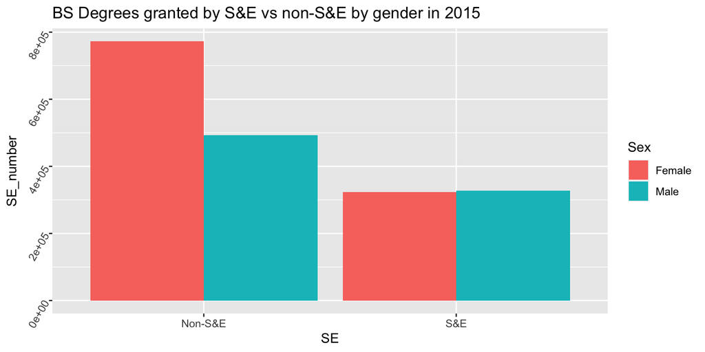

```r
  filter(wsci, Year == 2015 & Degree == "BS") %>%
  mutate(SE = ifelse(Field!="Non-S&E" , "S&E", "Non-S&E")) %>%
  group_by(SE, Sex) %>%
  summarise(SE_number = sum(Number)) %>%
  ggplot(aes(x = SE, y = SE_number, fill = Sex)) +
  geom_bar(stat = "identity", position = "dodge") +
  theme(axis.text.y = element_text(angle = 60)) +
  ggtitle("BS Degrees granted by S&E vs non-S&E by gender in 2015")
```

**Student Answer:** In this dataset, looking at year 2015 and BS degree awarded, there are about 60% female and 40% male. However, In certain field, such as Computer Science, Engineering, over 75% of the awarded BS degrees in 2015 are for male. Other science field such as Earth, Atmospheric and Ocean Science, Physical sciences, Math and Statistics, over 50% of the awarded BS degree are for male. Indeed, there is an hugh underrepresentation of female in these S&E field.

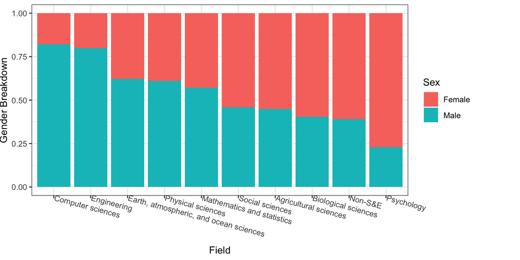

```r
  male_data <- wsci %>% filter(Year == 2015 & Degree == "BS" & Sex == "Male") %>% arrange(Field)
  female_data <-wsci %>% filter(Year == 2015 & Degree == "BS" & Sex == "Female") %>% arrange(Field)
  ratio <- male_data$Number / female_data$Number
  order <- data.frame(male_data$Field, ratio) %>% rename(Field = "male_data.Field")

  wsci %>%
  filter(Year == 2015 & Degree == "BS") %>%
  inner_join(order, by = "Field") %>%
  ggplot(aes(x = reorder(Field, -ratio), y = Number, fill = Sex)) +
  geom_bar(stat = "identity", position = "fill") +
  labs(x = "Field",
       y = "Gender Breakdown") +
  theme_bw() +
  theme(plot.margin = margin(t = 5, r = 50, b = 5, l = 0, unit = "pt"),
        axis.text.x = element_text(angle = -15, vjust = 0, hjust = 0))
```

## 3.3 EDA bringing type of degree, field and gender in 2015

Describe the number of people by type of degree, field, and gender. Do you see any evidence of gender effects over different types of degrees? Again, provide graphs to summarize your findings.

**Student Answer:** The pattern of gender imbalance in S&E field is similar across BS, MS and PhD degree, if not worse for PhDs.

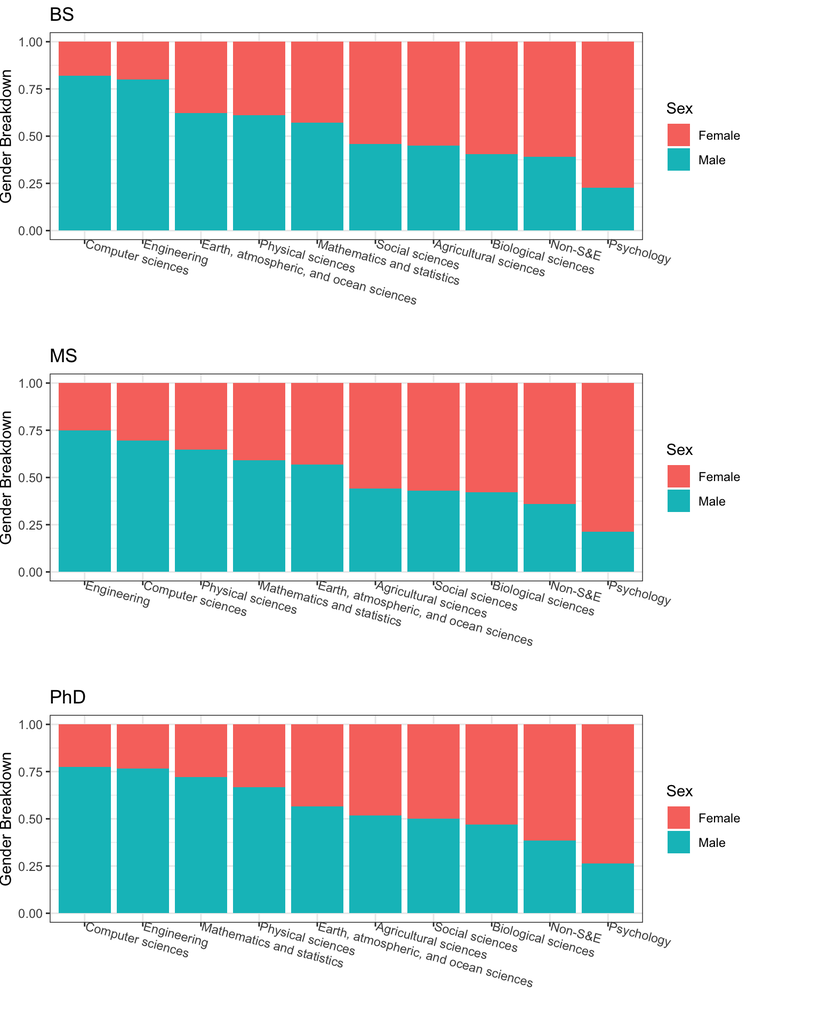

```r
plot_summary <- function(degree_type)
{
  male_data <- wsci %>% filter(Year == 2015 & Degree == degree_type & Sex == "Male") %>% arrange(Field)
  female_data <-wsci %>% filter(Year == 2015 & Degree == degree_type & Sex == "Female") %>% arrange(Field)
  ratio <- male_data$Number / female_data$Number
  order <- data.frame(male_data$Field, ratio) %>% rename(Field = "male_data.Field")

  figure <-
  filter(wsci, Year == 2015 & Degree == degree_type) %>%
  inner_join(order, by = "Field") %>%
  ggplot(aes(x = reorder(Field, -ratio), y = Number, fill = Sex)) +
  geom_bar(stat = "identity", position = "fill") +
  labs(x = "",
       y = "Gender Breakdown",
       title = degree_type) +
  theme_bw() +
  theme(plot.margin = margin(t = 5, r = 50, b = 5, l = 0, unit = "pt"),
        axis.text.x = element_text(angle = -15, vjust = 0, hjust = 0))

  return(figure)
}

f1 <- plot_summary("BS")
f2 <- plot_summary("MS")
f3 <- plot_summary("PhD")

grid.arrange(f1, f2, f3, nrow = 3)
```

## 3.4 EDA bring all variables

In this last portion of the EDA, we ask you to provide evidence numerically and graphically: Do the number of degrees change by gender, field, and time?

**Student Answer:** The total number of degrees awarded are increasing over the years. This is true for both gender, and most of the fields.

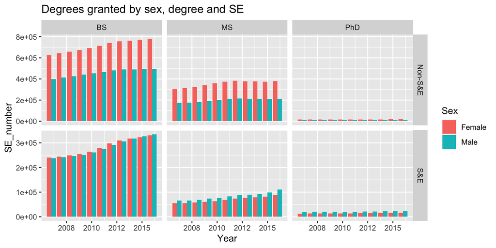

```r
  wsci %>%
  mutate(SE = ifelse(Field!="Non-S&E" , "S&E", "Non-S&E")) %>%
  group_by(SE, Sex, Year, Degree) %>%
  summarise(SE_number = sum(Number)) %>%
  ggplot(aes(x = Year, y = SE_number, fill = Sex)) +
  geom_bar(stat = "identity", position = "dodge") +
  facet_grid(SE~Degree, scales = "free_y") +
  ggtitle("Degrees granted by sex, degree and SE")
```

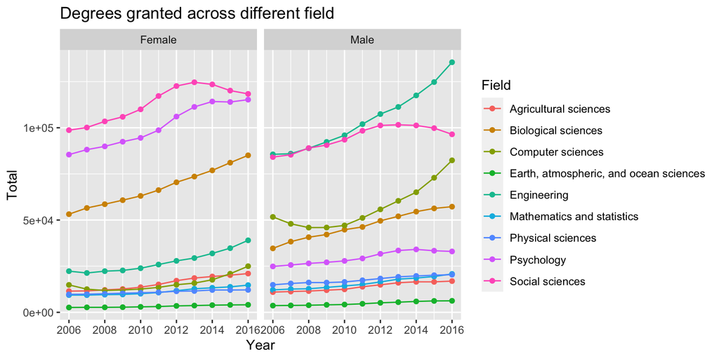

```r
  wsci %>%
  filter(Field != "Non-S&E") %>%
  group_by(Field, Year, Sex) %>%
  summarise(Total = sum(Number)) %>%
  ggplot(aes(x = Year, y = Total, group = Field, color = Field)) +
  geom_point() + geom_line() +
  facet_grid(~Sex) +
  ggtitle("Degrees granted across different field")
```

**Student Answer:** The gender breakdown of SE/non-SE field and degree type have stayed relatively the same for the past 10 years.

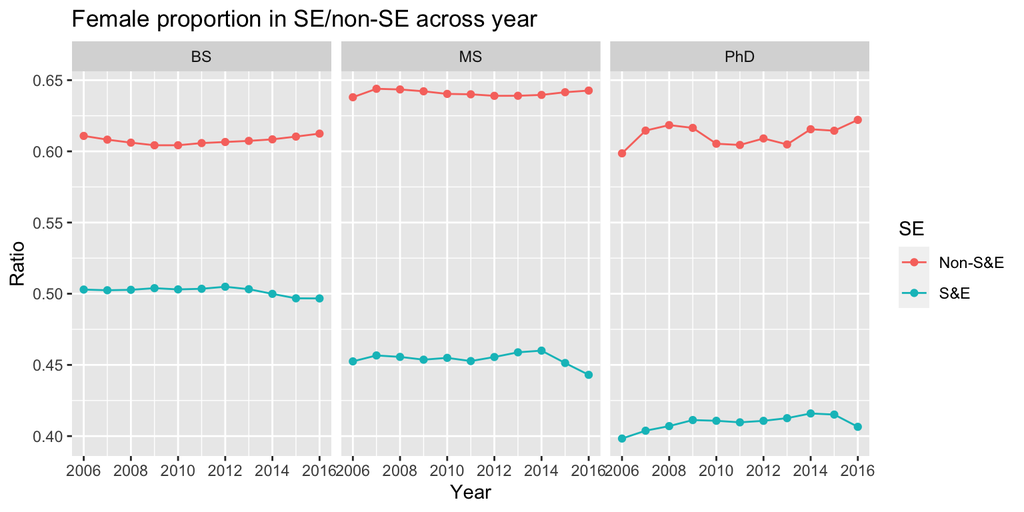

```r
  wsci %>%
  mutate(SE = ifelse(Field!="Non-S&E" , "S&E", "Non-S&E")) %>%
  group_by(SE, Sex, Year, Degree) %>%
  summarise(Total = sum(Number)) %>%
  group_by(SE, Year, Degree) %>%
  mutate(Ratio = Total / sum(Total)) %>%
  filter(Sex == "Female") %>%
  ggplot(aes(x = Year, y = Ratio, group = SE, color = SE)) +
  geom_point() + geom_line() + facet_grid(~Degree) +
  ggtitle("Female proportion in SE/non-SE across year")
```

**Student Answer:** The same (i.e., the relatively constant gender breakdown) is true for almost all of the field in our dataset.

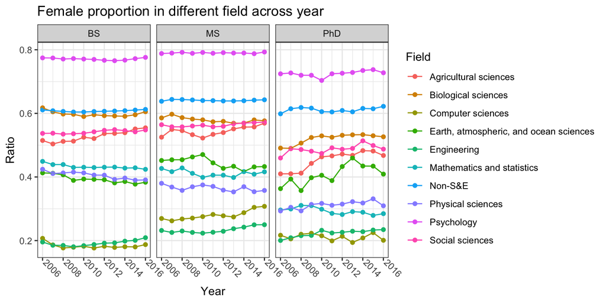

```r
  wsci %>%
  group_by(Field, Degree, Year) %>%
  mutate(Ratio = Number / sum(Number)) %>%
  filter(Sex == "Female") %>%
  ggplot(aes(x = Year, y = Ratio, group = Field, color = Field)) +
  geom_point() + geom_line() +
  facet_grid(~Degree) +
  ggtitle("Female proportion in different field across year") +
  theme_bw() +
  theme(axis.text.x = element_text(angle = -45, vjust = 0, hjust = 0))
```

## 3.5 Women in Data Science

Finally, is there evidence showing that women are underrepresented in data science? Data science is an interdisciplinary field of computer science, math, and statistics. You may include year and/or degree.

**Student Answer:** Yes, female proportion in both computer science, and math/statistics are below 60%, furthermore, females are extremely underrepresented in the field of computer science.

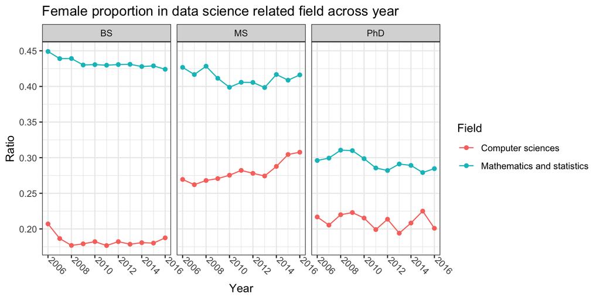

```r
wsci %>%
  filter(Field %in% c("Computer sciences", "Mathematics and statistics")) %>%
  group_by(Field, Degree, Year) %>%
  mutate(Ratio = Number / sum(Number)) %>%
  filter(Sex == "Female") %>%
  ggplot(aes(x = Year, y = Ratio, group = Field, color = Field)) +
  geom_point() + geom_line() +
  facet_grid(~Degree) +
  ggtitle("Female proportion in data science related field across year") +
  theme_bw() +
  theme(axis.text.x = element_text(angle = -45, vjust = 0, hjust = 0))
```

## 3.6 Final brief report

Summarize your findings focusing on answering the questions regarding if we see consistent patterns that more males pursue science-related fields. Any concerns with the data set? How could we improve on the study?

**Student Answer:** Throughout our analysis, we have seen evidences that indicate:

1. Female are generally underrepresented in S&E related field.
2. The underrepresentation is particularly severe for the field of Computer Science, Engineering, Math/Statistics, and Physical Science.
3. Over the past 10 years, there seems to be very little, if any reduction in the gender imbalance in S&E fields.

In this dataset, overall, there seems to be more data regarding degree awarded for female than male (F:M ~ 3:2). I am not sure if this is expected since the gender breakdown in the general population here in the US is rather balanced. This could be a potential indication of bias in the sampling.

# 4 Case study 3: Major League Baseball

We would like to explore how payroll affects performance among Major League Baseball teams. The data is prepared in two formats record payroll, winning numbers/percentage by team from 1998 to 2014.

Here are the datasets:

-`MLPayData_Total.csv`: wide format -`baseball.csv`: long format

Feel free to use either dataset to address the problems.

## 4.1 EDA: Relationship between payroll changes and performance

Payroll may relate to performance among ML Baseball teams. One possible argument is that what affects this year’s performance is not this year’s payroll, but the amount that payroll increased from last year. Let us look into this through EDA.

Create increment in payroll

1. To describe the increment of payroll in each year there are several possible approaches. Take 2013 as an example:
   - option 1: diff: payroll_2013 - payroll_2012
   - option 2: log diff: log(payroll_2013) - log(payroll_2012)

Explain why the log difference is more appropriate in this setup.

Explanations: Using the log difference in this sort of time series model gives several advantages:

1. the nature of log difference makes it easier to track the changes. Increasing by 1% this year and decreasing by 1% next year would mean the value goes back to where it was under the log difference. Using absolute difference wouldn’t achieve so.
2. sometimes, the payroll might grow a lot for some teams, using log difference could serve as sort of smoother.
2. Create a new variable `diff_log=log(payroll_2013) - log(payroll_2012)`. Hint: use `dplyr::lag()` function.
3. Create a long data table including: team, year, diff_logpayroll, win_pct

A long data table means?

## 4.2 Exploratory questions

1. Which five teams had highest increase in their payroll between years 2010 and 2014, inclusive?

The teams with highest inter year increase in their payroll between years of 2010 and 2014 are Los Angeles Dodgers, Miami Marlins, Houston Astros, Kansas City Royals, and Texas Rangers.

2. Between 2010 and 2014, inclusive, which team(s) “improved” the most? That is, had the biggest percentage gain in wins?

The teams with biggest inter year improvement is Philadelphia Phillies(2011), Los Angeles Angels(2014), Washington Nationals(2012), Boston Red Sox(2013), Cincinnati Reds(2012), and New York Yankess(2011).

## 4.3 Do log increases in payroll imply better performance?

Is there evidence to support the hypothesis that higher increases in payroll on the log scale lead to increased performance?

Pick up a few statistics, accompanied with some data visualization, to support your answer.

First we need to make a variable diff_win_pct to characterize the increase in performance.

We then use ggplot to present the relationship the increase in performance (win_pct) and increase in payroll on the log scale

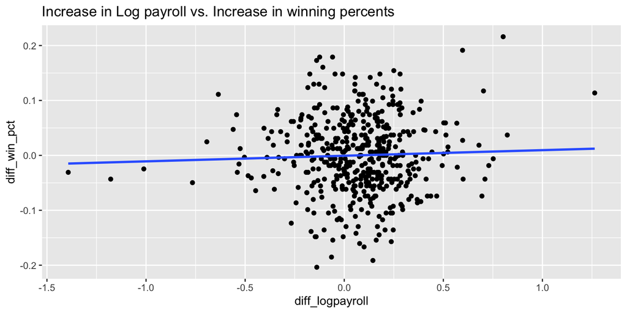

Also, since that there’s no randomized experiment, in order for us to say increase in payroll leads to increase in performance, the bar should be set relatively high. The regression can hardly be significant, as we can consider the points which are distant from the regression line by looking at their hat values.

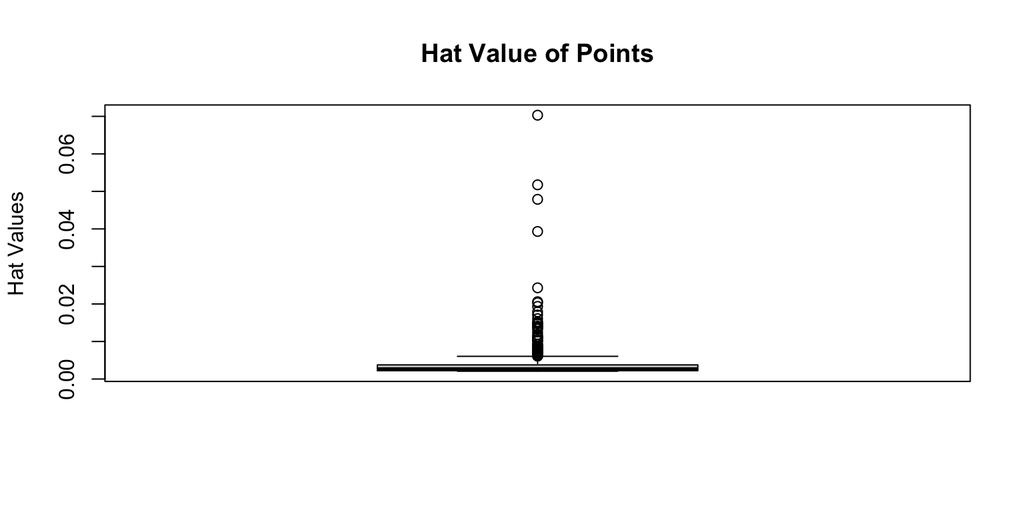

## 4.4 Comparison

Which set of factors are better explaining performance? Yearly payroll or yearly increase in payroll? What criterion is being used?

In order to compare which of the factors are better explanatory variables for performance, we may compare 1. the significance of the regression 2. the residuals from the fit.

[figure not shown]

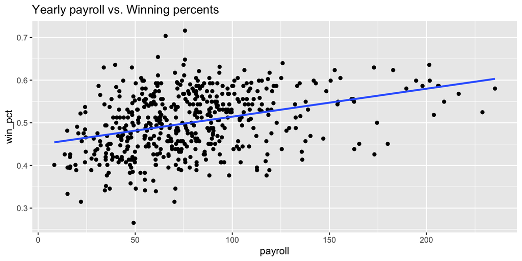

For this reason, I believe that Yearly payroll explains performance better. The real world intuition behind this is that the teams who have committed to providing higher pay attracts better players, whereas increase in the pay only stimulates short-term improvement in performance. The strong teams with originally very strong performance could hardly continue to increase their payroll, while their performance remains strong cross time.